```r
#install.packages("HistData",  repos = "http://cran.us.r-project.org", dependencies=TRUE)
library("HistData")
data(GaltonFamilies)
Galton2 <- data.frame(GaltonFamilies)
names(Galton2)
```

```
## [1] "family"          "father"          "mother"          "midparentHeight"
## [5] "children"        "childNum"        "gender"          "childHeight"
```

1. Obtain the summary of the data GaltonFamilies

```r
summary(Galton2)
```

```
##      family        father         mother      midparentHeight    children
##  185    : 15   Min.   :62.0   Min.   :58.00   Min.   :64.40   Min.   : 1.000
##  066    : 11   1st Qu.:68.0   1st Qu.:63.00   1st Qu.:68.14   1st Qu.: 4.000
##  120    : 11   Median :69.0   Median :64.00   Median :69.25   Median : 6.000
##  130    : 11   Mean   :69.2   Mean   :64.09   Mean   :69.21   Mean   : 6.171
##  166    : 11   3rd Qu.:71.0   3rd Qu.:65.88   3rd Qu.:70.14   3rd Qu.: 8.000
##  097    : 10   Max.   :78.5   Max.   :70.50   Max.   :75.43   Max.   :15.000
##  (Other):865
##     childNum         gender     childHeight
##  Min.   : 1.000   female:453   Min.   :56.00
##  1st Qu.: 2.000   male  :481   1st Qu.:64.00
##  Median : 3.000                Median :66.50
##  Mean   : 3.586                Mean   :66.75
##  3rd Qu.: 5.000                3rd Qu.:69.70
##  Max.   :15.000                Max.   :79.00
##
```

2. Are there any data that should be coded missing?

```r
#install.packages("mice", repos = 'http://cran.rstudio.com')

library(mice)
```

[output not shown]

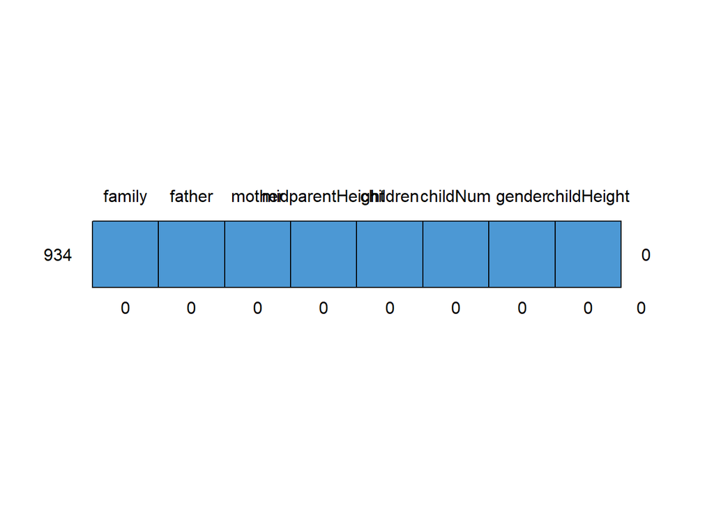

```r
M=md.pattern(Galton2)
```

```r
M
```

```
##     family father mother midparentHeight children childNum gender childHeight
## 934      1      1      1               1        1        1      1           1 0
##          0      0      0               0        0        0      0           0 0
```

Ans- No, we don’t see any variables which shows missing data

3. Which variables are numeric, integer, or factor?

```r
str(Galton2)
```

```
## 'data.frame':    934 obs. of  8 variables:
##  $ family         : Factor w/ 205 levels "001","002","003",..: 1 1 1 1 2 2 2 2 3 3 ...
##  $ father         : num  78.5 78.5 78.5 78.5 75.5 75.5 75.5 75.5 75 75 ...
##  $ mother         : num  67 67 67 67 66.5 66.5 66.5 66.5 64 64 ...
##  $ midparentHeight: num  75.4 75.4 75.4 75.4 73.7 ...
##  $ children       : int  4 4 4 4 4 4 4 4 2 2 ...
##  $ childNum       : int  1 2 3 4 1 2 3 4 1 2 ...
##  $ gender         : Factor w/ 2 levels "female","male": 2 1 1 1 2 2 1 1 2 1 ...
##  $ childHeight    : num  73.2 69.2 69 69 73.5 72.5 65.5 65.5 71 68 ...
```

Ans- Numeric Variables- ‘father’, ‘mother’, ‘midparentHeight’, ‘childHeight’ Interger Variables- ‘children’, ‘childNum’ Factor- ‘family’, ‘gender’

4. What is the R command for obtaining the levels of a factor?

Ans- R command for obtaining levels of a factor are - levels(dataname)

5. Use this command to determine the levels of gender

```r
levels(Galton2$gender)
```

```
## [1] "female" "male"
```

6. Are the labels sufficiently informational?

```r
 str(Galton2$gender)
```

```
##  Factor w/ 2 levels "female","male": 2 1 1 1 2 2 1 1 2 1 ...
```

Ans- The lables of ‘Levels’ has reference level set at ‘female’ meaning female having lower value and male having higher value. This is not the general trend followed now. Also, from above str command we can infer that Female has been assigned numeric value ‘1’ and male value of’2’ which is not consistent with the ‘Gender’ variable generally defined.

Thus the lables are not sufficiently informational.

7. Remove the family and childNum columns

```r
dt<-subset(Galton2, select=-c(family,childNum))
```

8. Produce the summary table of the modified dataframe

```r
summary(dt)
```

```
##      father         mother      midparentHeight    children         gender
##  Min.   :62.0   Min.   :58.00   Min.   :64.40   Min.   : 1.000   female:453
##  1st Qu.:68.0   1st Qu.:63.00   1st Qu.:68.14   1st Qu.: 4.000   male  :481
##  Median :69.0   Median :64.00   Median :69.25   Median : 6.000
##  Mean   :69.2   Mean   :64.09   Mean   :69.21   Mean   : 6.171
##  3rd Qu.:71.0   3rd Qu.:65.88   3rd Qu.:70.14   3rd Qu.: 8.000
##  Max.   :78.5   Max.   :70.50   Max.   :75.43   Max.   :15.000
##   childHeight
##  Min.   :56.00
##  1st Qu.:64.00
##  Median :66.50
##  Mean   :66.75
##  3rd Qu.:69.70
##  Max.   :79.00
```